# GLMM_LongitudinalData

Pietro Mingardi

## Introduction

This dataset contains data from an experimental study in which foreign students with different native languages were tested in a psycholinguistic task designed to assess their acquisition of Italian. In this task, participants were presented with words and were asked to select which of two images correctly represented the meaning of each word. We aim to analyze whether their performance improved from the first administration of the task (Time 0) to the second administration (Time 1), six months later. We also aim to determine whether any observed improvements were mediated by their native language.

```r
#import dataset
df = read_excel("Df.xlsx")

df$Word = as.factor(df$Word)
df$puID = as.factor(df$puID)
df$time = as.factor(df$time)
df$LanguageFamily = as.factor(df$LanguageFamily)

summary(df)
```

```
##        Word           puID         Correct          time       LanguageFamily
##  parola1 :  66   p1     :  64   Min.   :0.0000   time0:1056   Austrian:576
##  parola10:  66   p10    :  64   1st Qu.:0.0000   time1:1056   Belgian :320
##  parola11:  66   p11    :  64   Median :1.0000                French  :512
##  parola12:  66   p12    :  64   Mean   :0.6723                German  :256
##  parola13:  66   p13    :  64   3rd Qu.:1.0000                Italian :192
##  parola14:  66   p14    :  64   Max.   :1.0000                Spanish :256
##  (Other) :1716   (Other):1728
```

```r
#check numerosity for each language family
numerosity = df %>%
  group_by(LanguageFamily) %>%
  summarise("num" = n_distinct(puID))

numerosity
```

```
## # A tibble: 6 × 2
##   LanguageFamily   num
##   <fct>          <int>
## 1 Austrian           9
## 2 Belgian            5
## 3 French             8
## 4 German             4
## 5 Italian            3
## 6 Spanish            4
```

The sample size is relatively small. Moreover, three participants reported Italian as their mother tongue; these students will therefore be excluded from the sample. Given that our primary interest is to test whether different native languages affect performance, and considering that the small number of participants within each Language Family would likely produce unstable effect estimates, we decided to aggregate participants based on the linguistic roots of their native language. French and Spanish will be grouped as Romance languages, while German and Austrian will be grouped as Germanic languages. Belgian participants will be classified according to their native language (four are French-speaking and one is German-speaking).

```r
#recodify languages
df_new <- df %>%
  filter(LanguageFamily != "Italian") %>%   # elimina italiani
  mutate(LangGroup = case_when(
    LanguageFamily %in% c("French", "Spanish") ~ "Romance",
    LanguageFamily %in% c("German", "Austrian") ~ "Germanic",
    LanguageFamily == "Belgian" & puID != "p3" ~ "Romance",
    LanguageFamily == "Belgian" & puID == "p3" ~ "Germanic"
  ), LangGroup = factor(LangGroup))

df_new %>%
  group_by(LangGroup) %>%
  summarise("n" = n_distinct(puID))
```

```
## # A tibble: 2 × 2
##   LangGroup     n
##   <fct>     <int>
## 1 Germanic     14
## 2 Romance      16
```

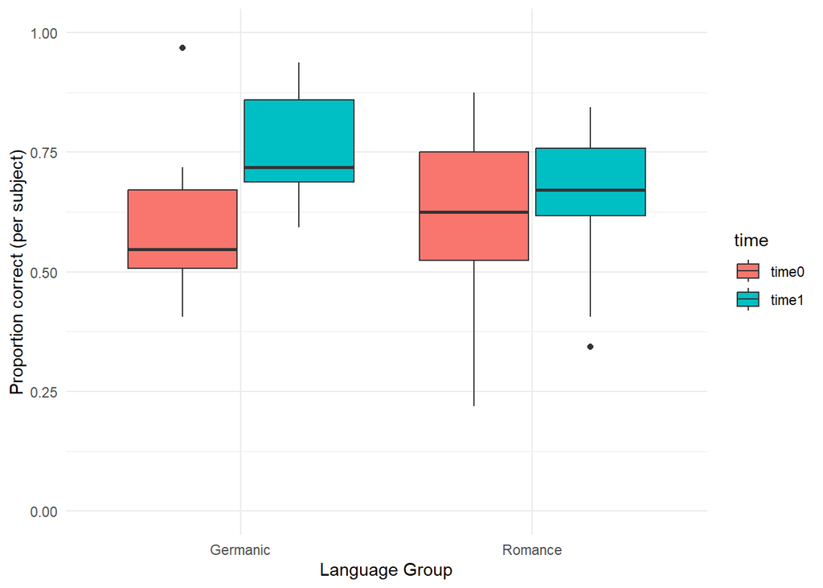

```r
#summary(df_new) #check new dataframe

df_new$LanguageFamily <- droplevels(df_new$LanguageFamily) #remove italian level


#plot performance differences between time0 and time1 for the two different LanguaGroup created
descr = df_new %>%
  group_by(puID, LangGroup, time) %>%
  summarise("meanCorrect" = mean(Correct), .groups = "drop")

ggplot(descr, aes(x = LangGroup, y = meanCorrect, fill = time))+
  geom_boxplot(position = position_dodge(width = 0.8)) +
  labs(
    x = "Language Group",
    y = "Proportion correct (per subject)",
    fill = "time"
  ) +
  ylim(0, 1) +
  theme_minimal()
```

```r
#check NA's
colSums(is.na(df_new))
```

```
##           Word           puID        Correct           time LanguageFamily
##              0              0              0              0              0
##      LangGroup
##              0
```

The plot indicates greater variability in performance for the Romance group, particularly at Time 0. In contrast, the Germanic group exhibits more homogeneous performance at both measurement points. Moreover, both groups appear to show an improvement from Time 0 to Time 1, as reflected by the higher median scores at the second measurement. The increase seems more pronounced for the Germanic group, although this pattern should be confirmed through statistical analysis.

## Model fitting

```r
#define costrast
contrasts(df_new$time) <-  matrix(c(-0.5, 0.5), ncol = 1)
contrasts(df_new$LangGroup) <-  matrix(c(-0.5, 0.5), ncol = 1)

model_DEF = glmer(Correct ~ time*LangGroup + (1 + time|puID) + (1|Word), family = "binomial",
                data= df_new, control=glmerControl(optimizer = "bobyqa", optCtrl = list(maxfun = 1e5)))

#check singularity of the random structure
isSingular(model_DEF)
```

```
## [1] FALSE
```

The random-effects structure of the model was initially specified to include random slopes for Times by the grouping variable ParticipantsID and random slopes for Time by the grouping variable Word. However, this structure gieven a singular fit warning. Therefore, we simplified the random structure stepwise until a model without convergence or singularity warnings was obtained. Specifically, we first removed the correlation between the random slopes of Time and the random intercept for the grouping variable Word. The final random-effects structure reported here corresponds to the most complex model that converged without warnings.

```r
summary(model_DEF) #let's have a look at the coefficients estimated by the model
```

```
## Generalized linear mixed model fit by maximum likelihood (Laplace
##   Approximation) [glmerMod]
##  Family: binomial  ( logit )
## Formula: Correct ~ time * LangGroup + (1 + time | puID) + (1 | Word)
##    Data: df_new
## Control: glmerControl(optimizer = "bobyqa", optCtrl = list(maxfun = 100000))
##
##      AIC      BIC   logLik deviance df.resid
##   2388.9   2433.4  -1186.5   2372.9     1912
##
## Scaled residuals:
##     Min      1Q  Median      3Q     Max
## -2.6695 -1.0770  0.5510  0.7042  1.5671
##
## Random effects:
##  Groups Name        Variance Std.Dev. Corr
##  Word   (Intercept) 0.02933  0.1713
##  puID   (Intercept) 0.24702  0.4970
##         time1       0.16130  0.4016   -0.20
## Number of obs: 1920, groups:  Word, 32; puID, 30
##
## Fixed effects:
##                  Estimate Std. Error z value        Pr(>|z|)
## (Intercept)        0.7254     0.1089   6.659 0.0000000000275 ***
## time1              0.4859     0.1265   3.840        0.000123 ***
## LangGroup1        -0.1995     0.2086  -0.957        0.338692
## time1:LangGroup1  -0.6079     0.2509  -2.423        0.015406 *
## ---
## Signif. codes:  0 '***' 0.001 '**' 0.01 '*' 0.05 '.' 0.1 ' ' 1
##
## Correlation of Fixed Effects:
##             (Intr) time1  LngGr1
## time1       -0.063
## LangGroup1  -0.075 -0.022
## tm1:LngGrp1 -0.021 -0.095 -0.072
```

To evaluate whether the two-way interaction was statistically significant, we compared the full model (including the interaction term) with a reduced model including only the main effects. Model comparison was performed using a likelihood ratio test based on the Chi-square statistic.

```r
model_base = glmer(Correct ~ time + LangGroup + (1 + time|puID) + (1|Word), family = "binomial",
                     data= df_new, control=glmerControl(optimizer = "bobyqa", optCtrl = list(maxfun = 1e5)))

anova(model_base, model_DEF, test = "Chisq" )
```

```
## Data: df_new
## Models:
## model_base: Correct ~ time + LangGroup + (1 + time | puID) + (1 | Word)
## model_DEF: Correct ~ time * LangGroup + (1 + time | puID) + (1 | Word)
##            npar    AIC    BIC  logLik deviance  Chisq Df Pr(>Chisq)
## model_base    7 2392.3 2431.2 -1189.1   2378.3
## model_DEF     8 2388.9 2433.4 -1186.5   2372.9 5.3128  1    0.02117 *
## ---
## Signif. codes:  0 '***' 0.001 '**' 0.01 '*' 0.05 '.' 0.1 ' ' 1
```

The interaction was statistically significant. To further investigate our hypotheses, we conducted post hoc tests.

```r
emm  = emmeans(model_DEF, ~time:LangGroup, type = "response")
emm
```

```
##  time  LangGroup  prob     SE  df asymp.LCL asymp.UCL
##  time0 Germanic  0.606 0.0443 Inf     0.517     0.689
##  time1 Germanic  0.772 0.0314 Inf     0.705     0.828
##  time0 Romance   0.631 0.0408 Inf     0.548     0.706
##  time1 Romance   0.672 0.0354 Inf     0.599     0.737
##
## Confidence level used: 0.95
## Intervals are back-transformed from the logit scale
```

```r
Germanic_time0 = c(1, 0, 0, 0)
Germanic_time1 = c(0, 1, 0, 0)
Romance_time0 = c(0, 0, 1, 0)
Romance_time1 = c(0, 0, 0, 1)

#wihtout correction
uncorrect_p = contrast(emm,  method = list("Germanic_time1 - Germanic_time0" = Germanic_time1 - Germanic_time0,
                             "Romance_time1 - Romance_time0" = Romance_time1 - Romance_time0,
                             "Germanic_time0 - Romance_time0" = Germanic_time0 - Romance_time0,
                             "Germanic_time1 - Romance_time1" = Germanic_time1 - Romance_time1
                             ))

uncorrect_p
```

```
##  contrast                        odds.ratio    SE  df null z.ratio p.value
##  Germanic_time1 / Germanic_time0      2.203 0.411 Inf    1   4.236  <.0001
##  Romance_time1 / Romance_time0        1.200 0.203 Inf    1   1.073  0.2831
##  Germanic_time0 / Romance_time0       0.901 0.226 Inf    1  -0.416  0.6773
##  Germanic_time1 / Romance_time1       1.655 0.390 Inf    1   2.138  0.0325
##
## Tests are performed on the log odds ratio scale
```

```r
#with p-value correction for multiple comparisons
correct_p = contrast(emm,  method = list("Germanic_time1 - Germanic_time0" = Germanic_time1 - Germanic_time0,
                             "Romance_time1 - Romance_time0" = Romance_time1 - Romance_time0,
                             "Germanic_time0 - Romance_time0" = Germanic_time0 - Romance_time0,
                             "Germanic_time1 - Romance_time1" = Germanic_time1 - Romance_time1
                             ), adjust ="holm")

correct_p
```

```
##  contrast                        odds.ratio    SE  df null z.ratio p.value
##  Germanic_time1 / Germanic_time0      2.203 0.411 Inf    1   4.236  0.0001
##  Romance_time1 / Romance_time0        1.200 0.203 Inf    1   1.073  0.5661
##  Germanic_time0 / Romance_time0       0.901 0.226 Inf    1  -0.416  0.6773
##  Germanic_time1 / Romance_time1       1.655 0.390 Inf    1   2.138  0.0976
##
## P value adjustment: holm method for 4 tests
## Tests are performed on the log odds ratio scale
```